# Assignment_5

Aditya Ashish Kulkarni

2024-04-06

```r
library(ISLR)
library(caret)
```

```r
library(ggplot2)
library(lattice)
#need to load dplyr and clustering packages
library(dplyr)
library(cluster)
library(factoextra)
library(NbClust)
library(ppclust)
library(dendextend)
library(tidyverse)
```

**Now importing the cereals data**

```r
library(readr)
data.df <- read_csv("Cereals.csv")
head(data.df)
```

```
# A tibble: 6 × 16
  name       mfr   type  calories protein   fat sodium fiber carbo sugars potass
  <chr>      <chr> <chr>    <dbl>   <dbl> <dbl>  <dbl> <dbl> <dbl>  <dbl>  <dbl>
1 100%_Bran  N     C           70       4     1    130  10     5        6    280
2 100%_Natu… Q     C          120       3     5     15   2     8        8    135
3 All-Bran   K     C           70       4     1    260   9     7        5    320
4 All-Bran_… K     C           50       4     0    140  14     8        0    330
5 Almond_De… R     C          110       2     2    200   1    14        8     NA
6 Apple_Cin… G     C          110       2     2    180   1.5  10.5     10     70
# ℹ 5 more variables: vitamins <dbl>, shelf <dbl>, weight <dbl>, cups <dbl>,
#   rating <dbl>
```

```r
#Let's analyzing data
str(data.df)
```

```
spc_tbl_ [77 × 16] (S3: spec_tbl_df/tbl_df/tbl/data.frame)
 $ name    : chr [1:77] "100%_Bran" "100%_Natural_Bran" "All-Bran" "All-Bran_with_Extra_Fiber" ...
 $ mfr     : chr [1:77] "N" "Q" "K" "K" ...
 $ type    : chr [1:77] "C" "C" "C" "C" ...
 $ calories: num [1:77] 70 120 70 50 110 110 110 130 90 90 ...
 $ protein : num [1:77] 4 3 4 4 2 2 2 3 2 3 ...
 $ fat     : num [1:77] 1 5 1 0 2 2 0 2 1 0 ...
 $ sodium  : num [1:77] 130 15 260 140 200 180 125 210 200 210 ...
 $ fiber   : num [1:77] 10 2 9 14 1 1.5 1 2 4 5 ...
 $ carbo   : num [1:77] 5 8 7 8 14 10.5 11 18 15 13 ...
 $ sugars  : num [1:77] 6 8 5 0 8 10 14 8 6 5 ...
 $ potass  : num [1:77] 280 135 320 330 NA 70 30 100 125 190 ...
 $ vitamins: num [1:77] 25 0 25 25 25 25 25 25 25 25 ...
 $ shelf   : num [1:77] 3 3 3 3 3 1 2 3 1 3 ...
 $ weight  : num [1:77] 1 1 1 1 1 1 1 1.33 1 1 ...
 $ cups    : num [1:77] 0.33 1 0.33 0.5 0.75 0.75 1 0.75 0.67 0.67 ...
 $ rating  : num [1:77] 68.4 34 59.4 93.7 34.4 ...
 - attr(*, "spec")=
  .. cols(
  ..   name = col_character(),
  ..   mfr = col_character(),
  ..   type = col_character(),
  ..   calories = col_double(),
  ..   protein = col_double(),
  ..   fat = col_double(),
  ..   sodium = col_double(),
  ..   fiber = col_double(),
  ..   carbo = col_double(),
  ..   sugars = col_double(),
  ..   potass = col_double(),
  ..   vitamins = col_double(),
  ..   shelf = col_double(),
  ..   weight = col_double(),
  ..   cups = col_double(),
  ..   rating = col_double()
  .. )
 - attr(*, "problems")=<externalptr>
```

```r
#Summary of data
summary(data.df)
```

```
     name               mfr                type              calories
 Length:77          Length:77          Length:77          Min.   : 50.0
 Class :character   Class :character   Class :character   1st Qu.:100.0
 Mode  :character   Mode  :character   Mode  :character   Median :110.0
                                                          Mean   :106.9
                                                          3rd Qu.:110.0
                                                          Max.   :160.0

    protein           fat            sodium          fiber
 Min.   :1.000   Min.   :0.000   Min.   :  0.0   Min.   : 0.000
 1st Qu.:2.000   1st Qu.:0.000   1st Qu.:130.0   1st Qu.: 1.000
 Median :3.000   Median :1.000   Median :180.0   Median : 2.000
 Mean   :2.545   Mean   :1.013   Mean   :159.7   Mean   : 2.152
 3rd Qu.:3.000   3rd Qu.:2.000   3rd Qu.:210.0   3rd Qu.: 3.000
 Max.   :6.000   Max.   :5.000   Max.   :320.0   Max.   :14.000

     carbo          sugars           potass          vitamins
 Min.   : 5.0   Min.   : 0.000   Min.   : 15.00   Min.   :  0.00
 1st Qu.:12.0   1st Qu.: 3.000   1st Qu.: 42.50   1st Qu.: 25.00
 Median :14.5   Median : 7.000   Median : 90.00   Median : 25.00
 Mean   :14.8   Mean   : 7.026   Mean   : 98.67   Mean   : 28.25
 3rd Qu.:17.0   3rd Qu.:11.000   3rd Qu.:120.00   3rd Qu.: 25.00
 Max.   :23.0   Max.   :15.000   Max.   :330.00   Max.   :100.00
 NA's   :1      NA's   :1        NA's   :2
     shelf           weight          cups           rating
 Min.   :1.000   Min.   :0.50   Min.   :0.250   Min.   :18.04
 1st Qu.:1.000   1st Qu.:1.00   1st Qu.:0.670   1st Qu.:33.17
 Median :2.000   Median :1.00   Median :0.750   Median :40.40
 Mean   :2.208   Mean   :1.03   Mean   :0.821   Mean   :42.67
 3rd Qu.:3.000   3rd Qu.:1.00   3rd Qu.:1.000   3rd Qu.:50.83
 Max.   :3.000   Max.   :1.50   Max.   :1.500   Max.   :93.70
```

Removing NA values from Data

```r
#Partitioning Data
#need to scale it

scaled.df = data.df

scaled.df[, c(4:16)] <- scale(data.df[, c(4:16)])

#omitting NA values
preprocess.df = na.omit(scaled.df)
#printing Head
head(scaled.df)
```

```
# A tibble: 6 × 16
  name  mfr   type  calories protein     fat sodium   fiber  carbo sugars potass
  <chr> <chr> <chr>    <dbl>   <dbl>   <dbl>  <dbl>   <dbl>  <dbl>  <dbl>  <dbl>
1 100%… N     C       -1.89    1.33  -0.0129 -0.354  3.29   -2.51  -0.234  2.58
2 100%… Q     C        0.673   0.415  3.96   -1.73  -0.0638 -1.74   0.222  0.516
3 All-… K     C       -1.89    1.33  -0.0129  1.20   2.87   -2.00  -0.463  3.14
4 All-… K     C       -2.92    1.33  -1.01   -0.235  4.97   -1.74  -1.60   3.29
5 Almo… R     C        0.160  -0.498  0.981   0.481 -0.483  -0.205  0.222 NA
6 Appl… G     C        0.160  -0.498  0.981   0.242 -0.274  -1.10   0.679 -0.407
# ℹ 5 more variables: vitamins <dbl>, shelf <dbl>, weight <dbl>, cups <dbl>,
#   rating <dbl>
```

**Question.1** **Apply hierarchical clustering to the data using Euclidean distance to the normalized measurements. Use Agnes to compare the clustering from single linkage, complete linkage, average linkage, and Ward. Choose the best method.**

Applying Euclidean method

```r
#dissimilarity matrix for numerical values
df.euclidean = dist(preprocess.df[, 4:16], method = "euclidean")
```

**Single Linkage method**

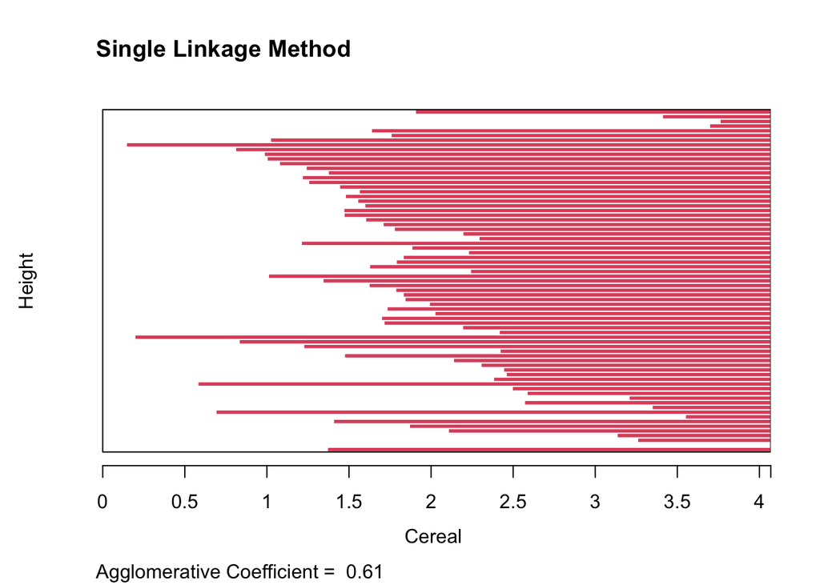

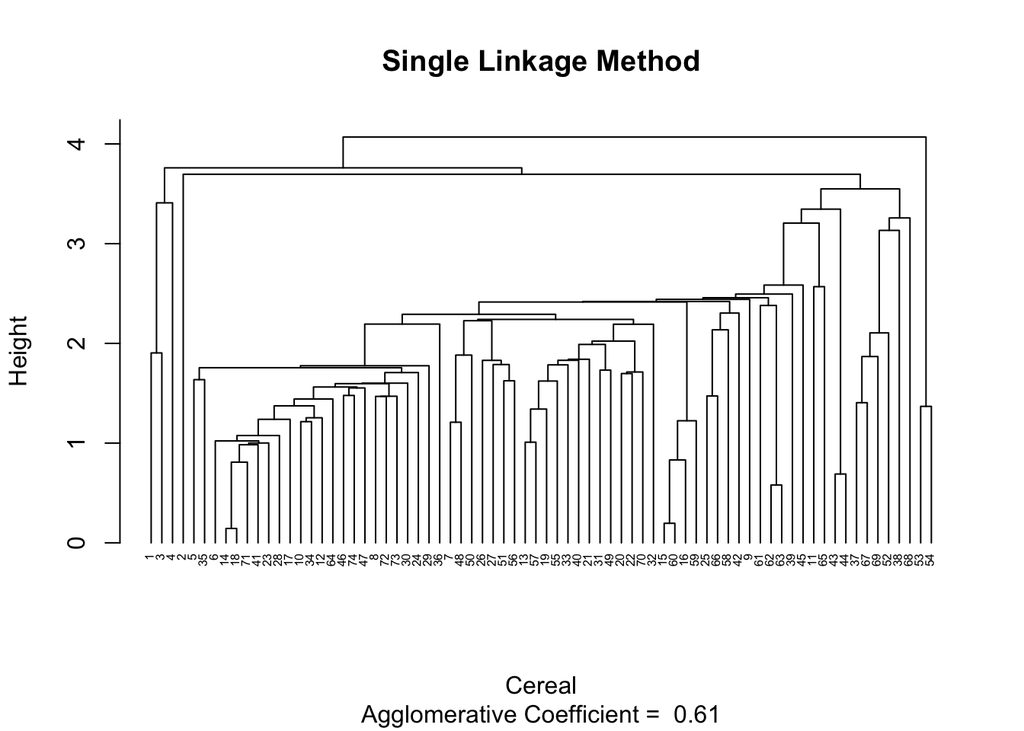

```r
#using Agnes for clustering
clust.single= agnes(df.euclidean, method = "single")
#plotting the cluster
plot(clust.single, main = "Single Linkage Method",
     xlab= "Cereal",
     ylab= "Height",
     cex.axis=1,
     cex=0.50,
     hang=-1)
```

```r
print(clust.single$ac)
```

```
[1] 0.6094447
```

**Complete Linkage Method**

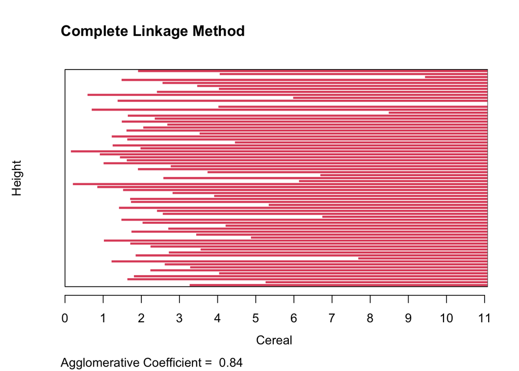

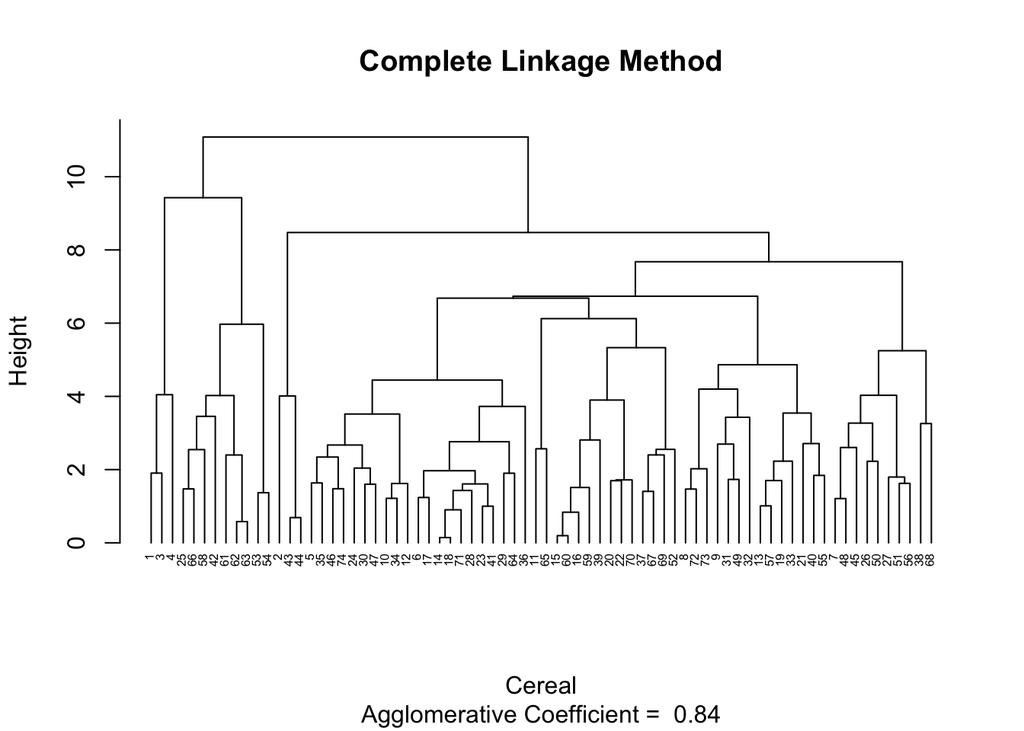

```r
#using Agnes for clustering
clust.com= agnes(df.euclidean, method = "complete")
#plotting the cluster
plot(clust.com, main = "Complete Linkage Method",
     xlab= "Cereal",
     ylab= "Height",
     cex.axis=1,
     cex=0.50,
     hang=-1)
```

```r
print(clust.com$ac)
```

```
[1] 0.8413498
```

**Average Linkage Method**

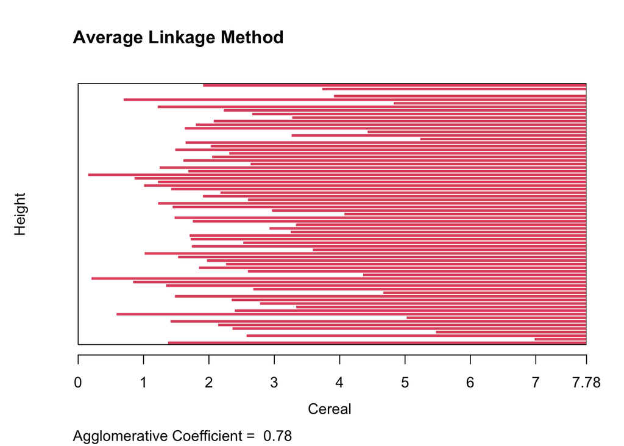

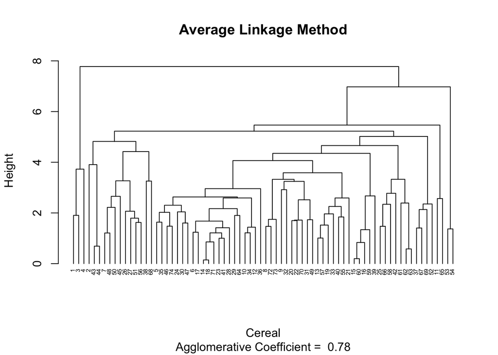

```r
#using Agnes for clustering
clust.avg= agnes(df.euclidean, method = "average")
#plotting the cluster
plot(clust.avg, main = "Average Linkage Method",
     xlab= "Cereal",
     ylab= "Height",
     cex.axis=1,
     cex=0.50,
     hang=-1)
```

```r
print(clust.avg$ac)
```

```
[1] 0.7814484
```

**Ward method**

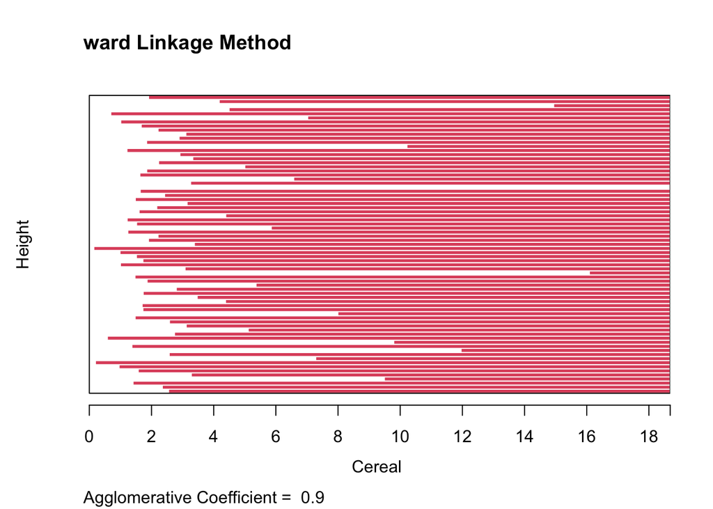

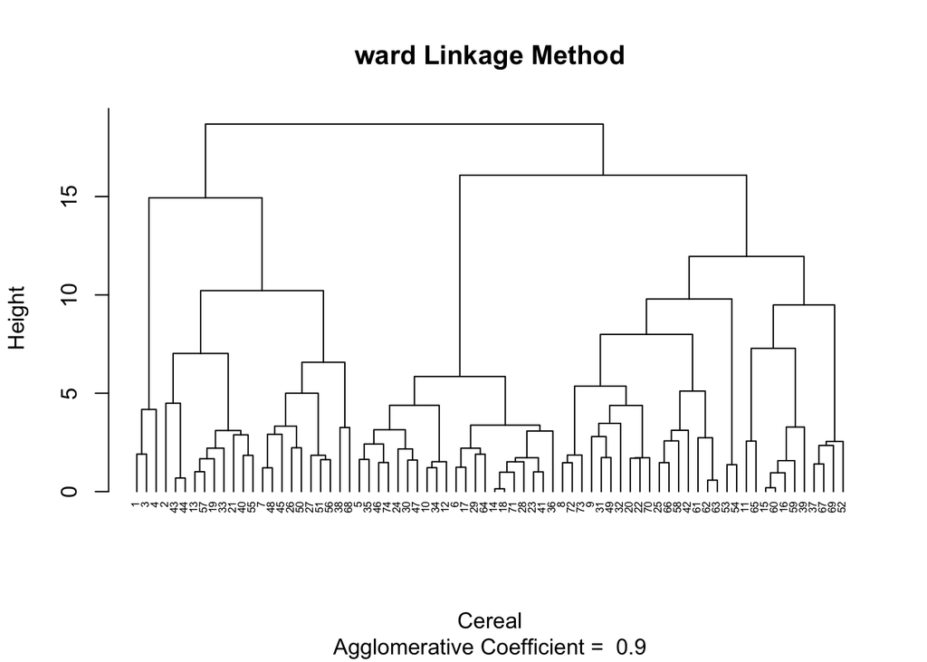

```r
#using Agnes for clustering
clust.ward= agnes(df.euclidean, method = "ward")
#plotting the cluster
plot(clust.ward, main = "ward Linkage Method",
     xlab= "Cereal",
     ylab= "Height",
     cex.axis=1,
     cex=0.50,
     hang=-1)
```

```r
print(clust.ward$ac)
```

```
[1] 0.9049881
```

**Answer:** As we can see above - Single linkage method : 0.6094447, Complete Linkage Method: 0.8413498, Average Linkage Method : 0.7814484, Ward Linkage Method: 0.9049881.

We can see that the Ward linkage method is the best method, it has highest coefficient.

**Question 2 : How many clusters would you choose?**

We need to use Silhouette and Elbow method to determine the appropriate cluster

**Silhouette Method**

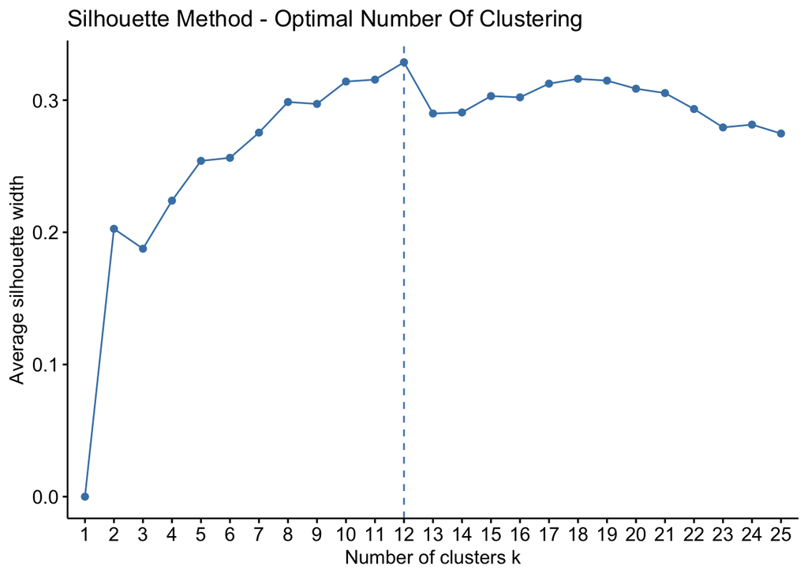

```r
#Using Silhouette method for optimal number of clusters
fviz_nbclust(preprocess.df[ , c(4:16)], hcut, method = "silhouette", k.max = 25) +
 labs(title = "Silhouette Method - Optimal Number Of Clustering")
```

Now, let’s use Elbow method on this

**Elbow Method**

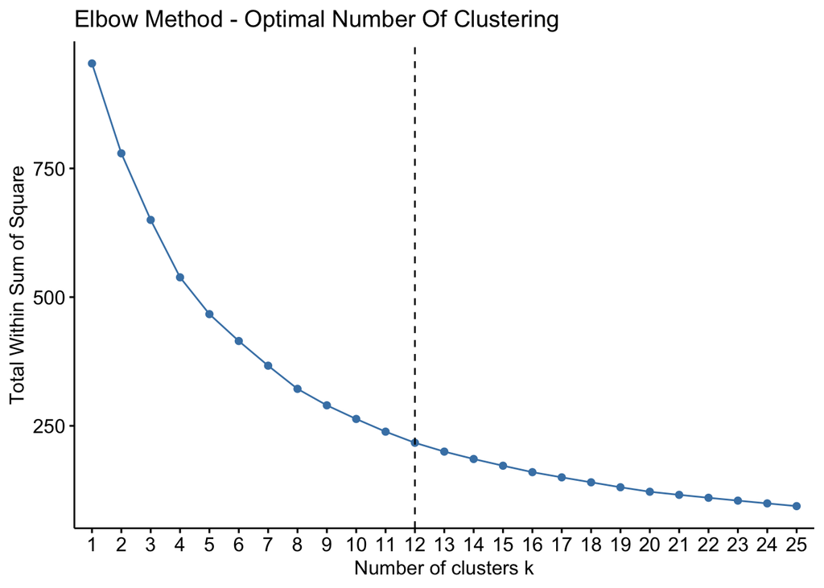

```r
#Using Elbow method for optimal number of clusters
fviz_nbclust(preprocess.df[ , c(4:16)], hcut, method = "wss", k.max = 25) +
 labs(title = "Elbow Method - Optimal Number Of Clustering") +
  geom_vline(xintercept = 12, linetype=2)
```

From above Silhouette method it defines that 12 clusters would be ideal choice…

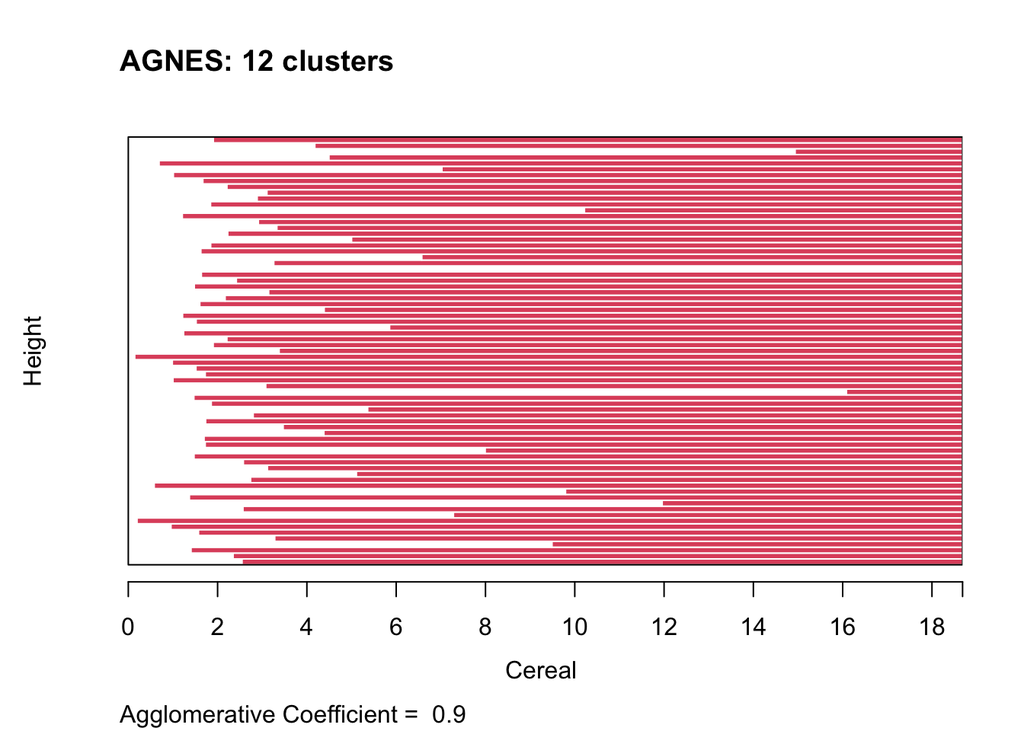

```r
#Plotting ward hierarchical tree , 12 color highlighted for reference
plot(clust.ward,
     main = "AGNES: 12 clusters",
     xlab = "Cereal",
     ylab = "Height",
     cex.axis = 1,
     cex = 0.50,
     hang= -1)
```

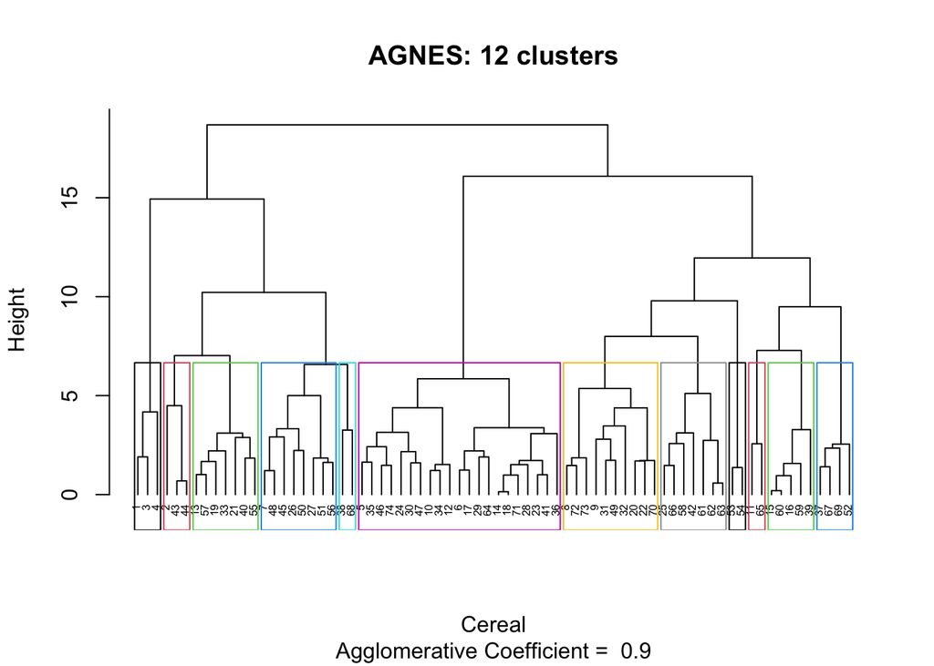

```r
rect.hclust(clust.ward, k=12, border = 1:12)
```

**Question 3: Comment on the structure of the clusters and on their stability. Hint: To check stability,partition the data and see how well clusters formed based on one part apply to the other part. To do this: ● Cluster partition A ● Use the cluster centroids from A to assign each record in partition B (each record is assigned to the cluster with the closest centroid). ● Assess how consistent the cluster assignments are compared to the assignments based on all the data.**

```r
#Making Partition A & B
set.seed(69)
partition.A = preprocess.df[1:55, 4:16]
partition.B = preprocess.df[56:74, 4:16]

#performing hierarchical clustering considering K=12

single.df = agnes(scale(partition.A), method = "single")
complete.df = agnes(scale(partition.A), method = "complete")
average.df = agnes(scale(partition.A), method = "average")
ward.df <- agnes(scale(partition.A), method = "ward")
ward.df.2 <- agnes(scale(partition.B), method = "ward")

cbind(single=single.df$ac, complete=complete.df$ac, average=average.df$ac, ward=ward.df$ac)
```

```
        single  complete   average      ward
[1,] 0.6564842 0.8120228 0.7449303 0.8808195
```

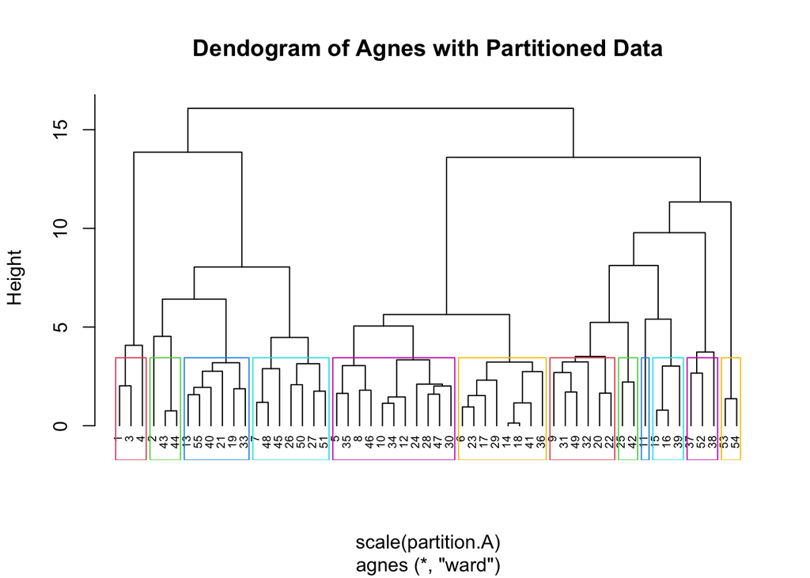

```r
pltree(ward.df, cex = 0.6, hang = -1, main = "Dendogram of Agnes with Partitioned Data")
rect.hclust(ward.df, k = 12, border = 2:7)
```

Now Calculate the Centroids, here we are forming 4 centroids

```r
part.2 = cutree(ward.df, k=12)
part.3 = cutree(ward.df.2,k=12)
df_2 = as.data.frame(cbind(part.3,partition.B))
```

```r
#centroids calculation
result.df <- as.data.frame(cbind(partition.A, part.2))
result.df[result.df$part.2==1,]
```

```
   calories  protein         fat     sodium    fiber     carbo     sugars
1 -1.892984 1.328607 -0.01290349 -0.3539844 3.292847 -2.508783 -0.2343906
3 -1.892984 1.328607 -0.01290349  1.1967306 2.873272 -1.996924 -0.4627711
4 -2.919461 1.328607 -1.00647256 -0.2346986 4.971147 -1.740994 -1.6046739
    potass   vitamins     shelf     weight      cups   rating part.2
1 2.575368 -0.1453172 0.9515734 -0.1967771 -2.110034 1.832188      1
3 3.143464 -0.1453172 0.9515734 -0.1967771 -2.110034 1.193099      1
4 3.285488 -0.1453172 0.9515734 -0.1967771 -1.379530 3.633385      1
```

```r
#Centroid 1

centroid.1=colMeans(result.df[result.df$part.2==1,])
result.df[result.df$part.2==2,]
```

```
    calories   protein      fat     sodium       fiber      carbo    sugars
2  0.6732089 0.4151897 3.961373 -1.7257708 -0.06375361 -1.7409943 0.2223705
43 2.2129244 1.3286071 1.974235 -0.7714846  0.35582142  0.3064419 0.9075122
44 2.2129244 1.3286071 1.974235 -0.1154129  0.35582142  0.3064419 0.9075122
      potass   vitamins     shelf     weight    cups     rating part.2
2  0.5160205 -1.2642598 0.9515734 -0.1967771 0.76901 -0.6180571      2
43 1.0131045 -0.1453172 0.9515734 -0.1967771 0.76901 -0.3935878      2
44 1.0131045 -0.1453172 0.9515734 -0.1967771 0.76901 -0.6069456      2
```

```r
#Centroid 2
centroid.2 <- colMeans(result.df[result.df$part.2==2,])
result.df[result.df$part.2==3,]
```

```
     calories    protein         fat     sodium       fiber       carbo
5   0.1599704 -0.4982277  0.98066557  0.2424445 -0.27354112 -1.10117049
8  -0.8665066 -0.4982277 -0.01290349  0.4810160  0.77539645  0.05051241
10  0.6732089 -1.4116451  0.98066557  0.7195875 -0.90290366 -0.71727619
12  0.6732089 -1.4116451  1.97423464  0.6003018 -0.90290366 -0.46134666
24  0.1599704 -1.4116451 -1.00647256  0.4810160 -0.48332864 -0.20541712
28  0.1599704 -1.4116451 -0.01290349 -0.2943415 -0.90290366 -0.46134666
30  0.1599704 -1.4116451 -0.01290349  1.4353022 -0.90290366  0.05051241
34  0.6732089 -1.4116451  0.98066557  0.7195875 -0.48332864 -0.71727619
35  0.1599704  0.4151897 -0.01290349  1.0774449 -0.27354112 -0.84524095
46 -0.3532681 -0.4982277 -0.01290349  0.7195875 -0.06375361  0.05051241
47  0.6732089 -0.4982277 -0.01290349  0.3617302 -0.90290366  0.05051241
       sugars     potass   vitamins     shelf     weight       cups     rating
5   0.6791317 -0.4071355 -0.1453172 -1.450759 -0.1967771 -0.3052601 -0.9365625
8  -0.2343906  0.3739965 -0.1453172 -1.450759 -0.1967771 -0.6490266  0.4594871
```

[output cut: 21 more lines]

```r
#Centroid 3

centroid.3 <- colMeans(result.df[result.df$part.2==3,])
result.df[result.df$part.2==4,]
```

```
     calories    protein         fat     sodium      fiber      carbo    sugars
6   0.1599704 -0.4982277 -1.00647256 -0.4136273 -0.4833286 -0.9732057 1.5926539
14  0.1599704 -1.4116451 -0.01290349  0.2424445 -0.9029037 -0.7172762 1.3642734
17  0.1599704 -1.4116451 -1.00647256 -0.8311275 -0.4833286 -0.4613467 1.1358928
18  0.1599704 -1.4116451 -0.01290349  0.2424445 -0.9029037 -0.7172762 1.3642734
23  0.1599704 -0.4982277 -0.01290349 -0.4136273 -0.4833286 -0.9732057 1.3642734
29 -0.3532681 -0.4982277 -1.00647256 -1.3679135 -0.9029037 -0.9732057 1.8210345
36  0.1599704 -1.4116451 -1.00647256  0.2424445 -0.9029037 -0.2054171 0.9075122
41  0.1599704 -0.4982277 -0.01290349  0.2424445 -0.9029037 -0.7172762 1.1358928
       potass   vitamins     shelf     weight      cups     rating part.2
6  -0.9752315 -0.1453172 -0.249593 -0.1967771 0.7690100 -0.6756899      4
14 -0.6201715 -0.1453172 -0.249593 -0.1967771 0.7690100 -1.4187264      4
17 -1.1172554 -0.1453172 -0.249593 -0.1967771 0.7690100 -0.4899817      4
18 -0.4781475 -0.1453172 -0.249593 -0.1967771 0.7690100 -1.4429256      4
23 -0.9752315 -0.1453172 -0.249593 -0.1967771 0.7690100 -0.7444941      4
29 -0.8332075 -0.1453172 -1.450759 -0.1967771 0.2533603 -0.5277361      4
36 -0.9042195 -0.1453172 -1.450759 -0.1967771 2.1870466 -0.9911728      4
41 -0.6201715 -0.1453172 -0.249593 -0.1967771 0.7690100 -1.1341114      4
```

```r
#Centroid 4

centroid.4 = colMeans(result.df[result.df$part.2==4,])

centroid = rbind(centroid.1, centroid.2, centroid.3, centroid.4)
df.2= as.data.frame(rbind(centroid[,-14], partition.B))
```

Let’s figure out the Distance

```r
Dist.1 <- get_dist(df.2)
Matrix.1 <- as.matrix(Dist.1)

dataframe= data.frame(data=seq(1, nrow(partition.B), 1), Clusters= rep(0, nrow(partition.B)))
for(i in 1:nrow(partition.B))
  {dataframe[i,2] <- which.min(Matrix.1[i+4, 1:4])}
dataframe
```

```
   data Clusters
1     1        3
2     2        3
3     3        3
4     4        3
5     5        3
6     6        4
7     7        3
8     8        3
9     9        4
10   10        3
11   11        4
12   12        3
13   13        2
14   14        3
15   15        3
16   16        4
17   17        3
18   18        3
19   19        3
```

```r
cbind(df_2$part.3, dataframe$Clusters)
```

```
      [,1] [,2]
 [1,]    1    3
 [2,]    2    3
 [3,]    3    3
 [4,]    4    3
 [5,]    4    3
 [6,]    5    4
 [7,]    6    3
 [8,]    6    3
 [9,]    7    4
[10,]    8    3
[11,]    5    4
[12,]    9    3
[13,]   10    2
[14,]   11    3
[15,]    9    3
[16,]    7    4
[17,]   12    3
[18,]   12    3
[19,]   12    3
```

Comparing clusters to check stability finally :

```r
table(df_2$part.3==dataframe$Clusters)
```

```
FALSE  TRUE
   18     1
```

Hence, it is highly **unstable** because we have very less “TRUE” values.

**Question 4:The elementary public schools would like to choose a set of cereals to include in their daily cafeterias. Every day a different cereal is offered, but all cereals should support a healthy diet. For this goal, you are requested to find a cluster of “healthy cereals.” Should the data be normalized? If not, how should they be used in the cluster analysis?**

```r
#Clustrign "Healthy Cereals"

#Selecting columns which indicates the healthy cereals
healthy_c = preprocess.df[,c("calories", "protein", "fat", "fiber", "carbo", "sugars", "potass", "vitamins")]

#We have already normalized the data above so Now Don't need to normalie it...

#Now applying Euclidean method on the data
distance = dist(healthy_c, method = "euclidean")

hc = hclust(distance, method = "ward")
```

```
The "ward" method has been renamed to "ward.D"; note new "ward.D2"
```

```r
# we have K= 12 so need to make 12 clusters for this data

preprocess.df$cluster = cutree(hc, k = 12)

#Now only selecting Numeric columns

numeric_col = preprocess.df[, sapply(preprocess.df, is.numeric)]

#Now creating cluster summary

clust_summary = aggregate(. ~ cluster, data = numeric_col, FUN = mean)

print(clust_summary)
```

```
   cluster    calories     protein         fat      sodium       fiber
1        1 -2.23514255  1.32860712 -0.34409318  0.20268253  3.71242164
2        2  0.27402344  0.21220808  1.31185526 -0.24795260  0.02948529
3        3  0.15997044 -0.98538361 -0.34409318 -0.05974616 -0.73507365
4        4  2.00762903  0.78055668  1.37809320  0.06351580  0.27190641
5        5 -0.62699526  0.04982277 -0.67528287 -0.51700829  0.35582142
6        6  0.67320894 -1.41164506  1.31185526  0.67982562 -0.76304532
7        7 -0.14797266  2.05934104  0.18581032  0.01580149 -0.31549862
8        8  0.08665066 -0.62871587 -0.72259568  1.21377145 -0.78302508
9        9  0.67320894  0.41518972 -0.01290349  0.51083744  1.29986523
10      10 -0.09664881 -0.04151897 -0.26129576  0.74940899 -0.37843488
11      11  1.69968594  0.41518972 -0.01290349  0.24244446  0.35582142
12      12 -2.91946055 -0.95493637 -1.00647256 -1.90469943 -0.69311615
         carbo     sugars      potass   vitamins      shelf     weight
1  -2.08223369 -0.7672786  3.00144048 -0.1453172  0.9515734 -0.1967771
```

[output cut: 24 more lines]

**Answer :** Here, We have already done the normalizing on the data above So , Don’t need to normalize it again..

So, This cereal will be the great fit for childrens growth and strength.